# R Notebook

```r
heart <- read.csv("../HeartRate.csv")
```

[output not shown]

1. Log-in to AsULearn and import the file HeartRate.csv located at the Data Sets folder to R. This file contains heart rate data for 130 minutes.
1. Based on the sample ACF plot and the sample PACF plot of the heart rate data $Y_t$, is an MA(q) model or an AR(p) model more appropriate for $Y_t$? Explain. What is the most likely value of either p or q? Explain.

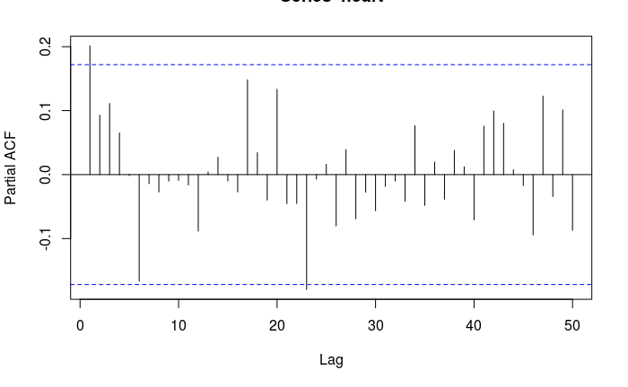

2. Fit an AR(1) and MA(1) models to the heart rate data. Based on the AIC and the log likelihood, which model fits the data better? Explain.

```r
modelAR1heart <- arima(heart,c(1,0,0))
modelMA1heart <- arima(heart,c(0,0,1))
modelAR1heart
```

```
Call:
arima(x = heart, order = c(1, 0, 0))

Coefficients:
         ar1  intercept
      0.2005    73.7605
s.e.  0.0857     0.7544

sigma^2 estimated as 47.48:  log likelihood = -435.4,  aic = 876.8
```

```r
modelMA1heart
```

```
Call:
arima(x = heart, order = c(0, 0, 1))

Coefficients:
         ma1  intercept
      0.1727    73.7605
s.e.  0.0805     0.7102

sigma^2 estimated as 47.79:  log likelihood = -435.82,  aic = 877.63
```

3. Test at the 5% level of significance whether the residuals of the better model in part 2 are white noise using the Ljung-Box-Pierce Test where H = 10. State the null and alternative hypotheses, the value of the test statistic, the p-value and the conclusion of the test. (Hint: Use the Box.test() function in R to implement this test)

```r
Box.test(modelMA1heart$residuals, type = "Ljung-Box", lag = 10)
```

```
    Box-Ljung test

data:  modelMA1heart$residuals
X-squared = 7.9591, df = 10, p-value = 0.6328
```

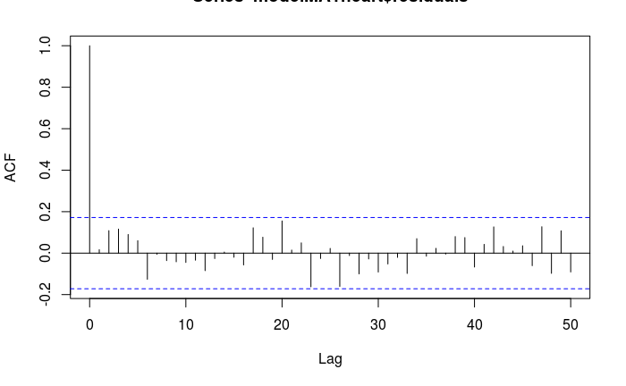

My answer is supported, as the residuals appear to be approximately white noise and not dependent on any lag.

5. Using the better model identified in part 2, predict the heart rate for the 131st minute.

```r
predict(modelMA1heart, n.ahead = 1)
```

```
$pred
Time Series:
Start = 131
End = 131
Frequency = 1
[1] 74.21687

$se
Time Series:
Start = 131
End = 131
Frequency = 1
[1] 6.912818
```

2. Import the data stored in AsULearn under the filename ElectricityPrice.csv.
1. Remove the overall increasing trend in this data using 1st order differencing. Attach and describe the time series plot of de-trended data. Is this stationary? Does it exhibit seasonality? If so, what is the seasonal period?

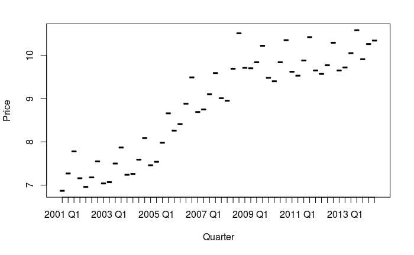

```r
plot(electric)
```

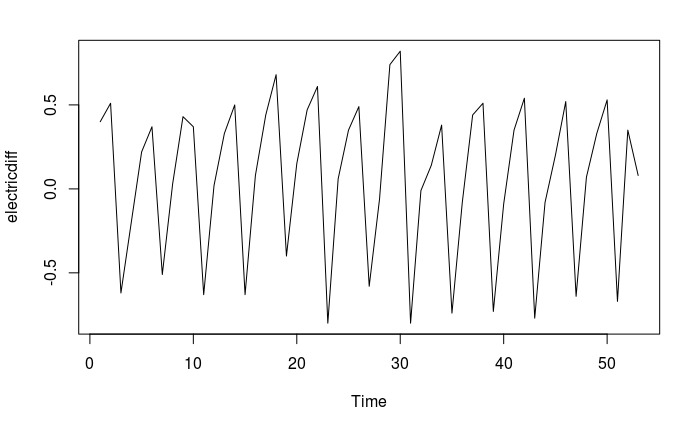

```r
electricdiff <- diff(electric$Price, lag = 1)
electricdiff <- ts(electricdiff)
plot.ts(electricdiff)
```

The time series plot of the de-trended differenced data appears to be stationary, with a constant mean around 0 and variance which appears constant.It appears to have a seasonality period of about 4, which would be a period of every 4 quarters(yearly).

2. Using a seasonal regression model with dummy variables, obtain the seasonally-adjusted de-trended electricity price data. (Hint: the seasonally-adjusted de-trended data are the residuals after fitting the regression model with the dummy variables Q1 which indicates if it’s in the 1st quarter, Q2 if in the 2nd quarter and Q3 if in the 3rd quarter and the commands Q1<-rep(c(1,0,0,0),13) and Q1[53]<-1 will create the dummy variable Q1 for the first quarter indicator, Q2<-rep(c(0,1,0,0),13) and Q2[53]<-0 will create the dummy variable Q2 for the 2nd quarter indicator and Q3<-rep(c(0,0,1,0),13) and Q3[53]<-0 will create the dummy variable Q3 for the 3rd quarter indicator)

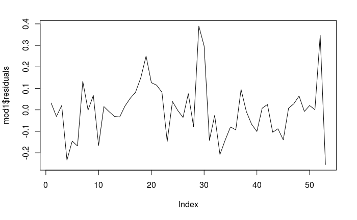

3. Obtain the best ARIMA model you can fit for the seasonally-adjusted data in part 2. Explain how you arrived at your final model.

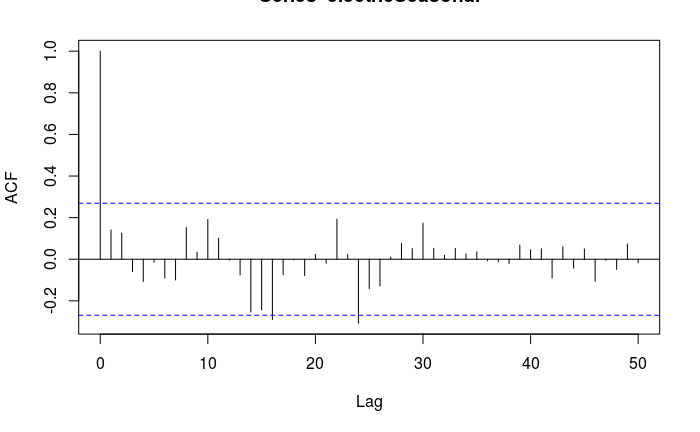

```r
acf(electricSeasonal, 50)
```

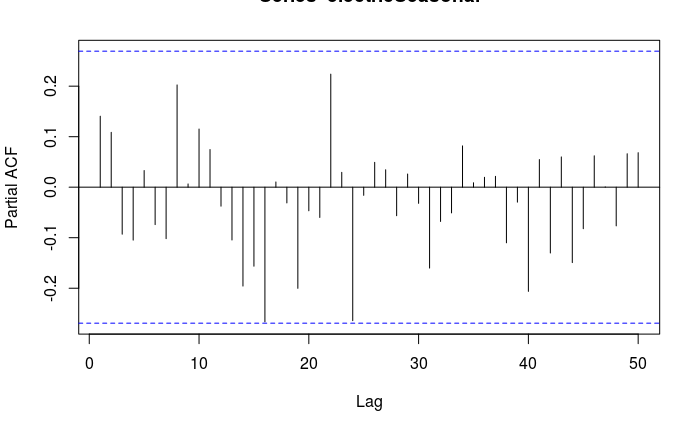

```r
pacf(electricSeasonal, 50)
```

```r
modelAR1electricity <- arima(electricSeasonal,c(1,0,0))
modelMA1electricity <- arima(electricSeasonal,c(0,0,1))
modelAR2electricity <- arima(electricSeasonal,c(2,0,0))
modelMA2electricity <- arima(electricSeasonal,c(0,0,2))
modelARMA11electricity <- arima(electricSeasonal,c(1,0,1))
modelARMA22electricity <- arima(electricSeasonal,c(2,0,2))
modelARMA12electricity <- arima(electricSeasonal,c(1,0,2))
modelARMA21electricity <- arima(electricSeasonal,c(2,0,1))
modelAR1electricity
```

```
Call:
arima(x = electricSeasonal, order = c(1, 0, 0))

Coefficients:
         ar1  intercept
      0.1485    -0.0007
s.e.  0.1396     0.0209

sigma^2 estimated as 0.01695:  log likelihood = 32.84,  aic = -59.69
```

```r
modelAR2electricity
```

```
Call:
arima(x = electricSeasonal, order = c(2, 0, 0))

Coefficients:
         ar1     ar2  intercept
      0.1184  0.1172    -0.0004
s.e.  0.1440  0.1538     0.0231

sigma^2 estimated as 0.01676:  log likelihood = 33.13,  aic = -58.26
```

```r
modelMA1electricity
```

```
Call:
arima(x = electricSeasonal, order = c(0, 0, 1))

Coefficients:
         ma1  intercept
      0.1215    -0.0006
s.e.  0.1277     0.0201

sigma^2 estimated as 0.01702:  log likelihood = 32.74,  aic = -59.47
```

```r
modelMA2electricity
```

```
Call:
arima(x = electricSeasonal, order = c(0, 0, 2))

Coefficients:
         ma1     ma2  intercept
      0.1437  0.2155    -0.0006
s.e.  0.1423  0.1706     0.0238

sigma^2 estimated as 0.01652:  log likelihood = 33.47,  aic = -58.94
```

```r
modelARMA11electricity
```

```
Call:
arima(x = electricSeasonal, order = c(1, 0, 1))

Coefficients:
         ar1      ma1  intercept
      0.3761  -0.2291    -0.0007
s.e.  0.4762   0.4947     0.0219

sigma^2 estimated as 0.01689:  log likelihood = 32.94,  aic = -57.87
```

```r
modelARMA22electricity
```

```
Call:
arima(x = electricSeasonal, order = c(2, 0, 2))

Coefficients:
          ar1      ar2     ma1     ma2  intercept
      -0.6452  -0.5321  0.7572  0.8560    -0.0011
s.e.   0.2557   0.2447  0.1957  0.1783     0.0205

sigma^2 estimated as 0.01544:  log likelihood = 34.87,  aic = -57.74
```

```r
modelARMA12electricity
```

```
Call:
arima(x = electricSeasonal, order = c(1, 0, 2))

Coefficients:
          ar1     ma1     ma2  intercept
      -0.2443  0.3713  0.2891    -0.0006
s.e.   0.3733  0.3525  0.2114     0.0233

sigma^2 estimated as 0.01642:  log likelihood = 33.61,  aic = -57.22
```

```r
modelARMA21electricity
```

```
Call:
arima(x = electricSeasonal, order = c(2, 0, 1))

Coefficients:
          ar1    ar2     ma1  intercept
      -0.7023  0.200  0.8420    -0.0009
s.e.   0.2820  0.146  0.2681     0.0217

sigma^2 estimated as 0.01669:  log likelihood = 33.19,  aic = -56.38
```

The best model for the data is an AR(1), because the ACF is sinusoidal and the AIC is the furthest from 0 of the 8 possible ARIMA models.

4. What is the forecast of the electricity price for the 3rd quarter of 2014? (Hint: the forecast for 3rd quarter of 2014 from the ARIMA model in part 3 is the estimate of the residual for the 3rd quarter of 2014 for the seasonal regression model so adding this residual to the seasonal regression model’s fitted value for 3rd quarter of 2014 will give an estimate of the de-trended electricity price for 3rd quarter of 2014. Finally, the forecast of the electricity price for the 3rd quarter of 2014 is the sum of the de-trended electricity price for 3rd quarter of 2014 and the original electricity price for the 2nd quarter of 2014.)

```r
-0.03845778 + -0.6744861 + electric$Price[54]
```

```
[1] 9.627056
```

The forecasted value of electricity in the third quarter of 2014 is $9.63.

5. Obtain a smoother version of the original electricity price data using two smoothing methods. What are the forecasts for the 3rd quarter of 2014 using these two methods? (Hint: the forecast for any future time period is the smoothed value at the 2nd quarter of 2014)

```r
plot.ts(electric$Price)
lines(ksmooth(time(electric$Price),electric$Price,"normal",bandwidth=5),col="red")
```

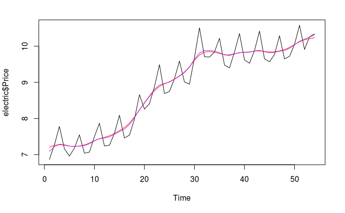

```r
lines(smooth.spline(time(electric$Price),electric$Price,spar=.5),col="purple")
```

```r
mod2 <- loess(electric$Price ~ time(electric$Price))
predict(mod2)[54]
```

```
[1] 10.11997
```

```r
mod3 <- smooth.spline(electric$Price)
predict(mod3)[2]
```

```
$y
 [1]  7.104952  7.130539  7.155290  7.179149  7.203779  7.231042  7.262116  7.298070  7.340529  7.390451  7.447985  7.513667  7.589036  7.674995  7.771253
[16]  7.877429  7.993557  8.118510  8.249601  8.383752  8.518793  8.652425  8.782131  8.906385  9.025532  9.139630  9.247750  9.349280  9.443693  9.529849
[31]  9.605097  9.667478  9.717544  9.756542  9.785754  9.806957  9.822908  9.835513  9.845354  9.853141  9.860507  9.868973  9.878783  9.890414  9.905619
[46]  9.925651  9.950620  9.980230 10.014761 10.053651 10.095344 10.138401 10.182487 10.227102
```

When we use a loess smoothing method, our predicted 3rd quarter 2014 price is $10.12, and when we use a smoothing spline we get $10.23.